# xwMOOC 딥러닝

R 케라스(keras) - 필기숫자 인식 데이터(MNIST)

Tidyverse Korea

Tidyverse Korea

2020-06-13

# 1 숫자 필기(MNIST) 데이터

필기숫자 인식 데이터는 [Yann LeCun](http://yann.lecun.com/exdb/mnist/) 웹사이트에서 다운로드 받을 수도 있고, [캐글 숫자인식기(Digit Recognizer)](https://www.kaggle.com/c/digit-recognizer) 웹사이트에서도 다운로드 받을 수 있고, `keras` 팩키지를 설치하면 팩키지 내부에 `dataset_mnist()` 함수를 통해 데이터를 불러올 수 있다.

# 2 숫자 필기 인식기 개발[^1]

## 2.1 데이터 가져오기

요즘들어 R 팩키지가 개발되면 유의미한 데이터를 포함시키는 경향이 있다. `keras` 팩키지에도 숫자 필기(MNIST) 데이터가 포함되어 있다. `? dataset_mnist()` 명령어를 실행하면 자세한 데이터에 대한 내용을 확인할 수 있다.

```r
# 0. 환경설치 -------------------------------------
library(keras)
library(tidyverse)

# 1. 데이터 불러오기 -------------------------------------
mnist_lst <- dataset_mnist()

# str(mnist_lst)
```

`str(mnist_lst)` 명령어로 리스트 형태로 `train`, `test`로 구분되어 있음이 확인된다.

## 2.2 데이터 살펴보기

관심이 있는 것은 필기숫자 데이터를 맞추는 것이다. 따라서 훈련데이터에 필기숫자 데이터가 0 – 9 까지 몇개나 되는지 살펴보고, 표본으로 50개를 뽑아 그래프로 그려본다. `display_digit` 함수는 사람이 이해하기 쉬운 형태 이미지로 시각화하기 위해 필요한 기능을 담고 있다.

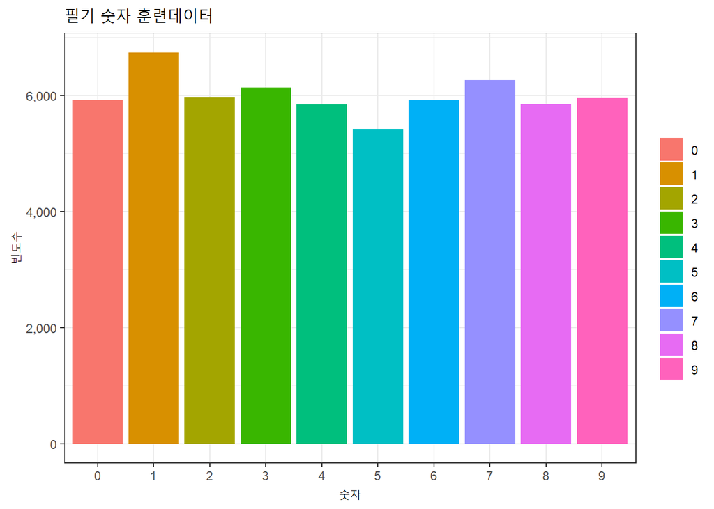

```r
# 2. 탐색적 데이터 분석 ----------------------------------
## 2.1. 사람손으로 쓴 손글씨 숫자
mnist_lst$train$y %>% as_tibble() %>%
  ggplot(aes(x=as.factor(value), fill=as.factor(value))) +
    geom_bar(stat="count") +
    scale_y_continuous(labels = scales::comma) +
    theme_bw(base_family = "AppleGothic") +
    labs(title="필기 숫자 훈련데이터 ", x="숫자", y="빈도수", fill="") +
    theme(legend.position = "right")
```

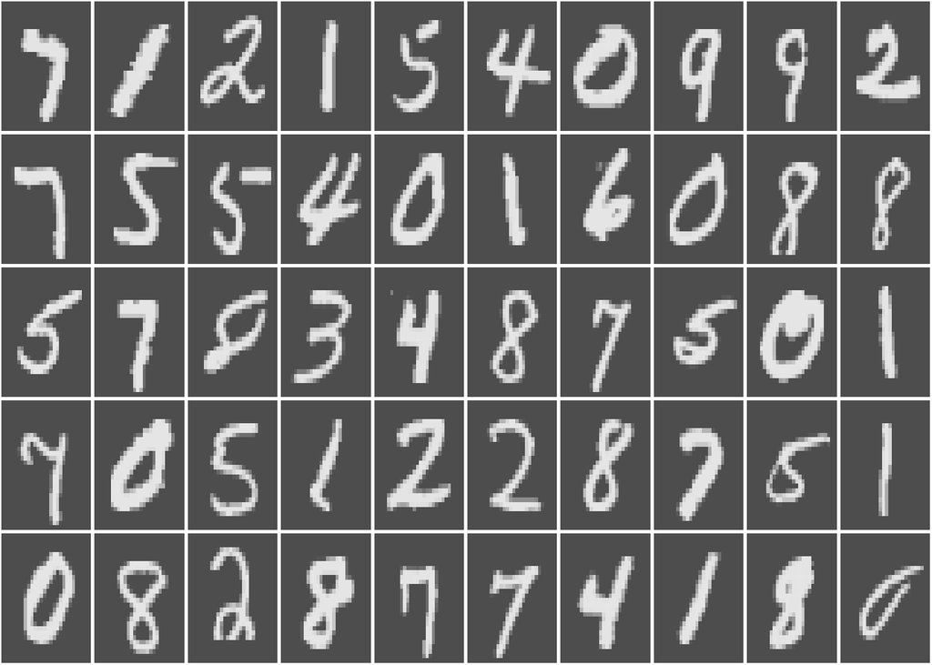

```r
## 2.2. 사람손으로 쓴 손글씨 숫자 시각화
mnist_smpl <- mnist_lst$train$x %>% tbl_df() %>%
    sample_n(50)

par(mfrow=c(5,10), mar=c(0.1,0.1,0.1,0.1))

display_digit <- function(input){
    m <- matrix(unlist(input), nrow = 28, byrow = FALSE)
    m <- t(apply(m, 2, rev))
    image(m, col=grey.colors(255), axes=FALSE)
}

for(i in 1:50) {
    display_digit(mnist_smpl[i,])
}
```

## 2.3 데이터 전처리

딥러닝 모형학습 전에 데이터를 훈련데이터와 검증데이터로 구분한다. `dataset_mnist()` 원본 데이터가 훈련과 검증 데이터로 구분이 되어 있어 이를 활용한다. 그리고, 기계학습을 위해 정규화 과정을 거친다. `dataset_mnist()` 데이터가 2D 이차원 배열이라, 이를 1차원 배열로 바꾸고 나서 255로 나눠 0 – 1 사이 값으로 정규화시킨다.

훈련데이터로 60,000 개 데이터, 검증데이터로 10,000 개 데이터가 준비되었다. `to_categorical()` 함수를 통해 종속변수를 One-Hot 인코딩 가변수 변환시킨다.

```r
# 3. 훈련/학습 데이터 분할 ----------------------------------

# 훈련데이터
train_x <- mnist_lst$train$x
train_y <- mnist_lst$train$y

# 검증데이터
test_x <- mnist_lst$test$x
test_y <- mnist_lst$test$y

# 4. 데이터 전처리 ----------------------------------
## 데이터 정규화(2D 배열 --> 1D 배열)
train_x <- array(as.numeric(train_x), dim = c(dim(train_x)[[1]], 784))
test_x <- array(as.numeric(test_x), dim = c(dim(test_x)[[1]], 784))

# RGB 값을 [0,1] 범위로 변환
train_x <- train_x / 255
test_x <- test_x / 255

cat(dim(train_x)[[1]], '개: 훈련표본\n') #60000 훈련표본
```

```
60000 개: 훈련표본
```

```r
cat(dim(test_x)[[1]], '개: 검증표본\n') #10000 검증표본
```

```
10000 개: 검증표본
```

```r
## 종속변수 가변수 변환
train_y <- to_categorical(train_y, 10)
test_y  <- to_categorical(test_y, 10)
```

## 2.4 딥러닝 모형 적합/훈련

훈련데이터와 검증데이터가 모두 준비되었으니, 모형을 초기화하고, 3층 구성을 갖는 신경망 모형을 준비한다. 더불어 손실함수와 측도도 함께 정의한후 `fit` 함수를 통해 준비한 신경망을 학습시킨다.

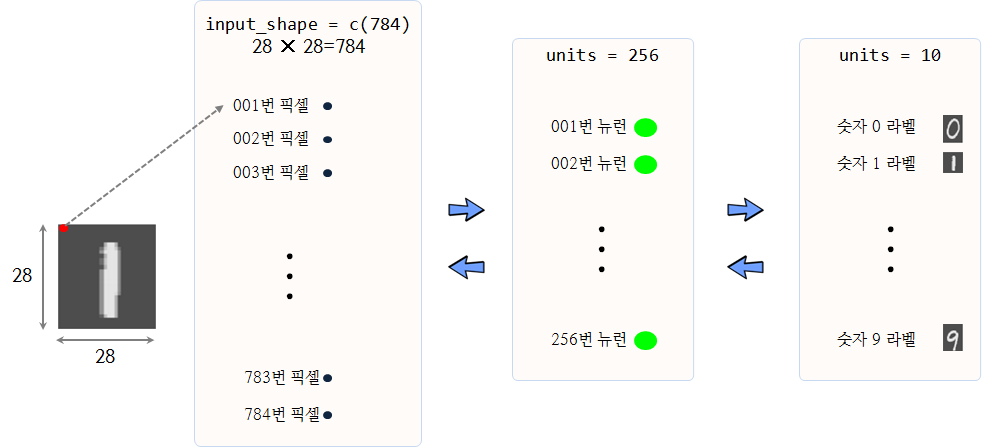

중간 dropout 계층과 128개 뉴런을 갖는 계층을 제외하면 이미지($28\times 28 = 784$) 픽셀을 입력으로 받아 256 뉴런에 넣는 계층 하나와 출력으로 0–9까지 숫자 10개 라벨을 갖는 출력 계층으로 단순화할 수 있다.

```r
# 5. 딥러닝 모형 ----------------------------------

## 5.1. 모형 초기화
model <- keras_model_sequential()

## 5.2. 모형 아키텍쳐 구성
model %>%
    layer_dense(units=256, activation="relu", input_shape=c(784))  %>%
    layer_dropout(rate=0.4) %>%
    layer_dense(units = 128, activation = "relu") %>%
    layer_dropout(rate=0.4) %>%
    layer_dense(units=10,activation="softmax")

summary(model)
```

```
Model: "sequential"
________________________________________________________________________________
Layer (type)                        Output Shape                    Param #
================================================================================
dense (Dense)                       (None, 256)                     200960
________________________________________________________________________________
dropout (Dropout)                   (None, 256)                     0
________________________________________________________________________________
dense_1 (Dense)                     (None, 128)                     32896
________________________________________________________________________________
dropout_1 (Dropout)                 (None, 128)                     0
________________________________________________________________________________
dense_2 (Dense)                     (None, 10)                      1290
================================================================================
Total params: 235,146
Trainable params: 235,146
Non-trainable params: 0
________________________________________________________________________________
```

```r
model %>%
    compile(loss ="categorical_crossentropy",
            optimizer = "adam",
            metrics= c("accuracy"))

## 5.3. 학습
history <- model %>%
  fit(train_x, train_y,
      epochs = 10,
      batch_size = 128,
      callbacks = callback_tensorboard(log_dir = "logs/run_b"),
      validation_split = 0.2)

history$metrics
```

```
$loss
 [1] 0.49022820 0.21925026 0.16743900 0.13963103 0.11957023 0.10724347
 [7] 0.09775513 0.08946584 0.08341284 0.07795728

$accuracy
 [1] 0.8503750 0.9354375 0.9507292 0.9583958 0.9630000 0.9670625 0.9702708
 [8] 0.9717500 0.9740000 0.9761458

$val_loss
 [1] 0.16820200 0.12418328 0.10922131 0.09696482 0.09177697 0.08403512
 [7] 0.08240505 0.08411978 0.08639239 0.07945904

$val_accuracy
 [1] 0.9508333 0.9640000 0.9683333 0.9715000 0.9713333 0.9750834 0.9754167
 [8] 0.9760833 0.9753333 0.9770000
```

## 2.5 모형평가

훈련데이터에 대한 딥러닝 학습을 수행한 결과를 시각적으로 평가한다. 딥러닝 모형이 과적합하지 않고 적절한 시점(이폭, Epochs)에서 정지한 것을 확인한 후, 검증데이터에 대해 손실오차와 정확도를 평가한다.

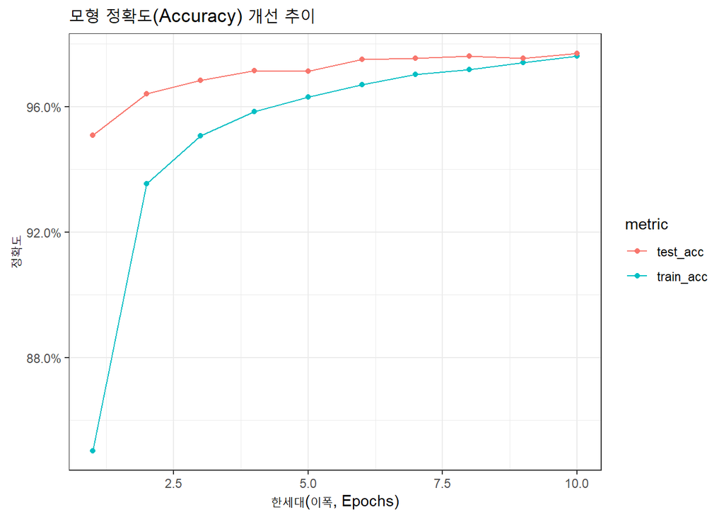

```r
## 5.4. 딥러닝 모형 평가
### 훈련데이터 모형 성능 시각화
eval_df <- tibble(train_acc = history$metrics$accuracy,
                  test_acc  = history$metrics$val_accuracy)

eval_df %>%
  mutate(epoch = 1:10) %>%
  pivot_longer(-epoch, names_to = "metric", values_to="accuracy") %>%
  ggplot(aes(x=epoch, y = accuracy, color=metric)) +
    geom_line() +
    geom_point() +
    labs(x="한세대(이폭, Epochs)", y="정확도",
         title = "모형 정확도(Accuracy) 개선 추이") +
    scale_y_continuous(labels = scales::percent) +
    theme_bw(base_family = "NanumGothic")
```

```r
# plot(history, labels=TRUE)

# 검증데이터 평가점수
score <- model %>%
    evaluate(test_x, test_y)

cat("손실오차(loss): ", scales::percent(score[[1]]), "\n")
```

```
손실오차(loss):  7%
```

```r
cat("정확도(Accurracy: ", scales::percent(score[[2]]), "\n")
```

```
정확도(Accurracy:  98%
```

[^1]: [Implementing Deep learning in R using Keras and Tensorflow packages for R and implementing a Multi layer perceptron Model on MNIST dataset and doing Digit Recognition](https://github.com/anishsingh20/Deep-Learning-in-R-using-Keras-and-Tensorflow-)